# Analysis of US Campaign donations by Pierre Hentges

Now I want to analyse the general election campaign using similar plots. First let’s look at the general election campaign donations of the different candidates.

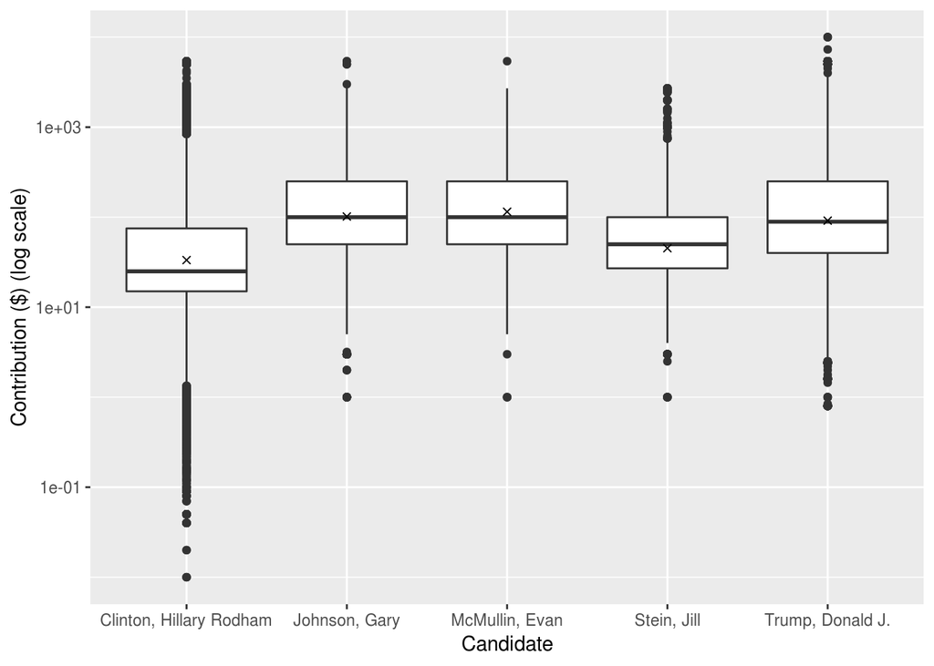

Perhaps surprisingly given observations for the primaries, Clinton received the lowest mean and median contributions of all the candidates in the general election campaign. Third party candidates and Trump were similar.

```
##    Min. 1st Qu.  Median    Mean 3rd Qu.    Max.
##    0.01   15.00   25.00  101.97   75.00 5400.00
```

```
##     Min.  1st Qu.   Median     Mean  3rd Qu.     Max.
##     0.80    40.00    89.05   223.77   250.00 10000.00
```

Across all quartiles, general election contributions received by Trump are much higher than those received by Clinton - with the mean being over twice as high for Trump.

Does this disparity in the contribution amount extend to the number of contributions?

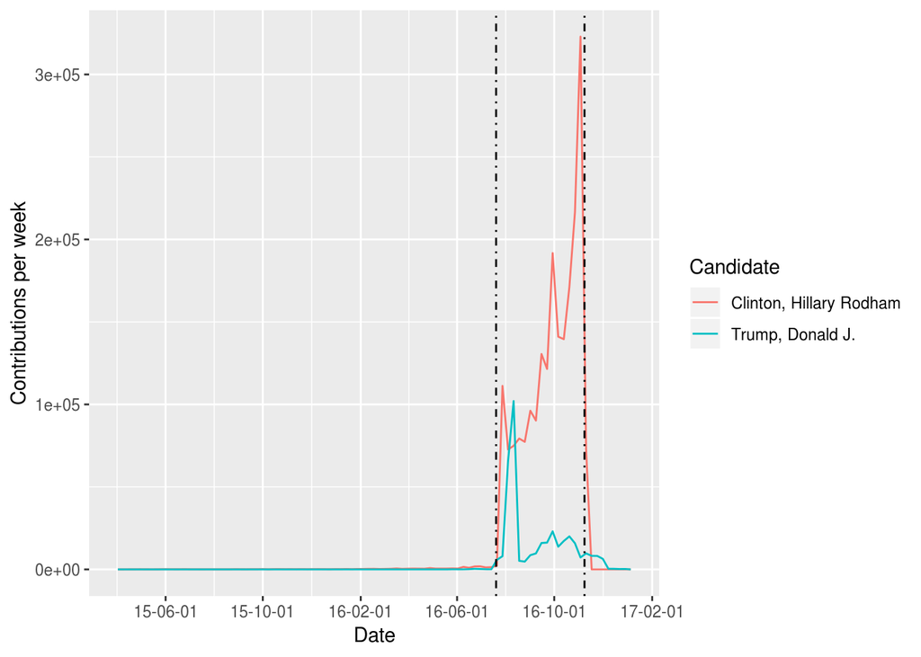

Vertical lines show the start and end of the general election campaigns.

# Bivariate Analysis

### Talk about some of the relationships you observed in this part of the investigation. How did the feature(s) of interest vary with other features in the dataset?

It’s important to distinguish between the number of contributions and the summed amount as these are often at odds. For example, while Sanders received far more contributions in the primaries, the the toal sum raised by Clinton is far higher.  
Similarly, while Democratic Party candidates received over wice as many donations than Republicna party candidates in the primaries, the sums raised are much closer together. What this observation means is that some candidates and parties are preferred by donors making large contributions.

Another interesting observation is that the total sums raised in the primaries by the main Republican candidates is significantly smaller those of the main Democratic candidates, probably because the number of Republican candidates was much larger. Plausibly, the total amount of finance that can potentially be raised in each party’s primaries is limited, so a larger number of candidates has this effect.

### Did you observe any interesting relationships between the other features (not the main feature(s) of interest)?

Analaysis of the contribution date reveals some interesting relationships: while most candidates in the primaries received the bulk of donations during the primaries contest as well as in the runup to the primaries, Trump received the majority of primaries donations after the primaries had finished.

As for the date of donations to the general election campaign, while the stream of donations to Clinton increased throughout the period of the general election, donations to the Trump general election peaked early on in the general election campaign, and then were at a relatively low level.

### What was the strongest relationship you found?

Comparing the support base of Clinton and Sanders using the occupation variable was instructive: some demographics had a very strong preference in who they donated to. In particular self-employed and unemployed donors were 80 times and over 20 times more likely to donate to Sanders. This may be indicative of Sanders mobilising different demographics.

# Multivariate Plots Section

The first relationship I want to get a better overview of is a comparison of candidates during the primaries race in terms of the relative density distribution of contributions over time - i.e. the variables of candidate, date, number of contributions restricted by election type.

In order to do this and capture how the primary race within a party unfolds, I will use violin plots to look at when candidates received most of the contributions. In volin plots, the relative density of contributions is visualised, i.e. contributions are normalised for each candidate. These will use Date as the x-variable, with Candidate as the third ctegorical variable, restricted to the primary election campaigns.

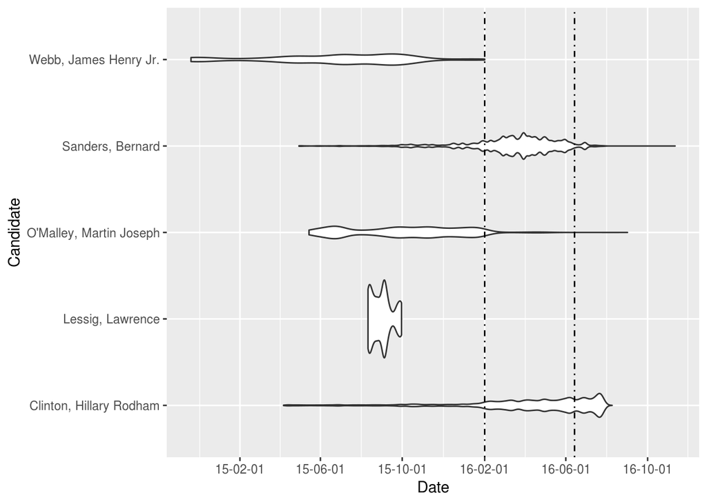

The violin plot shows the distribution in time of all of a campaign’s contributions, with the date on the horizontal axis.

Webb and Lessig received most contributions long before the primaries started. O’Malley received the bulk of contributions before 1. February, and while they markedly declined after he withdrew from the race, contributions continued for several months. It is not unusual to still receive donations after a candidate withdraws from the race: “In US elections, suspending a campaign allows candidates to cease active campaigning while still legally raising funds to pay off their debts” - source: https://en.wikipedia.org/wiki/2016_Democratic_Party_presidential_primaries

Here is the equivalent violin plot for the top 5 Republican candidates:

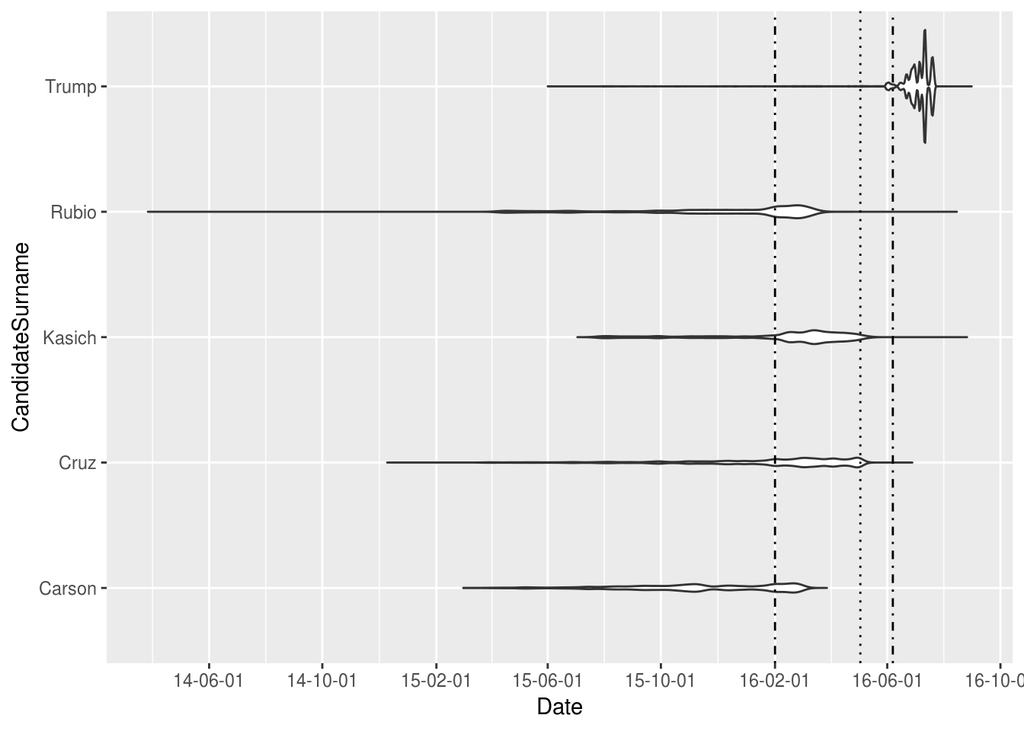

The start and the end of the primaries contests are shown by vertical lines. Cruz and Kasich suspended their campaigns after the Indiana primaries on 3.May (middle line), after which Trump remained as the sole candidate.

Surprisingly perhaps, Trump received the vast majority of primary contributions after the end of the primaries. This is quite different from the other candidates who received the bulk of contributions during their primary campaign. Also noticeable how much earlier Rubio started to receive campaign funding. Carson withdrew on 4.March, Rubio on 15. March.

Below is the correpsonding violon plot for the two main candidates in the general election:

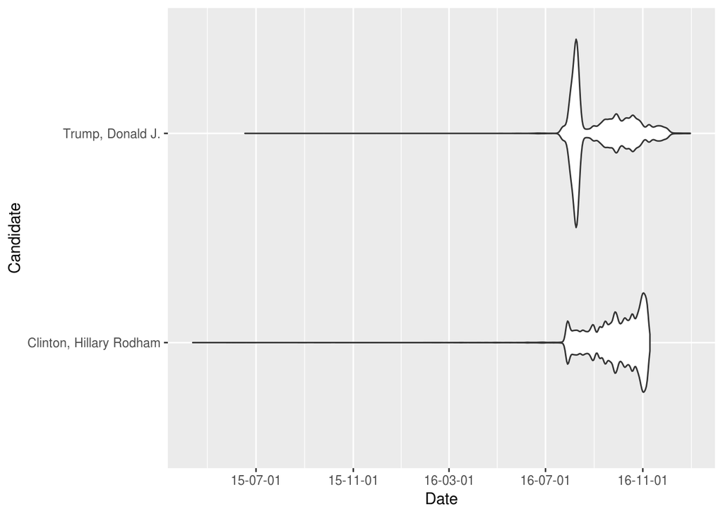

The previous analysis looked at the occupations of supporters of the different candidates, however this was limited by the number of occupation categories that could be investigated, and the metric (number of donations vs sums raised). Treemaps are an excellent multivariate type of plot to get a more complete understanding of different candidates’ support base. In the plots below, the size of rectangles is an expression of the number of contributions, with the colour hue encoding the median contribution donated by people with the same occupation.

First a treemap of the relative support bases of Clinton and Sanders during the primaries.

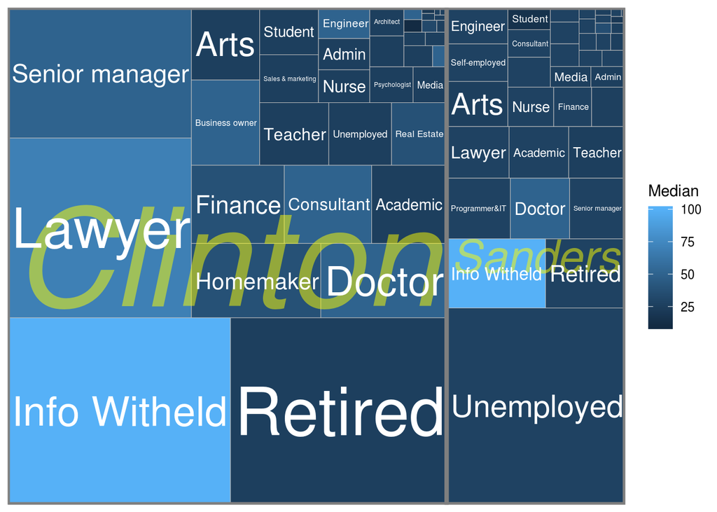

While the occupations that most strongly support Sanders - the unemployed, programmers- differ from Clinton, many of the remaining groups are quite similar. However there are some drastic differences in the total of contributions - for example lawyers and senior managers donate far more money to Clinton. It is also intersting that the group with the highest median donations is people witholding information on their occupation.

How about support for the top Republican candidates in the primaries?

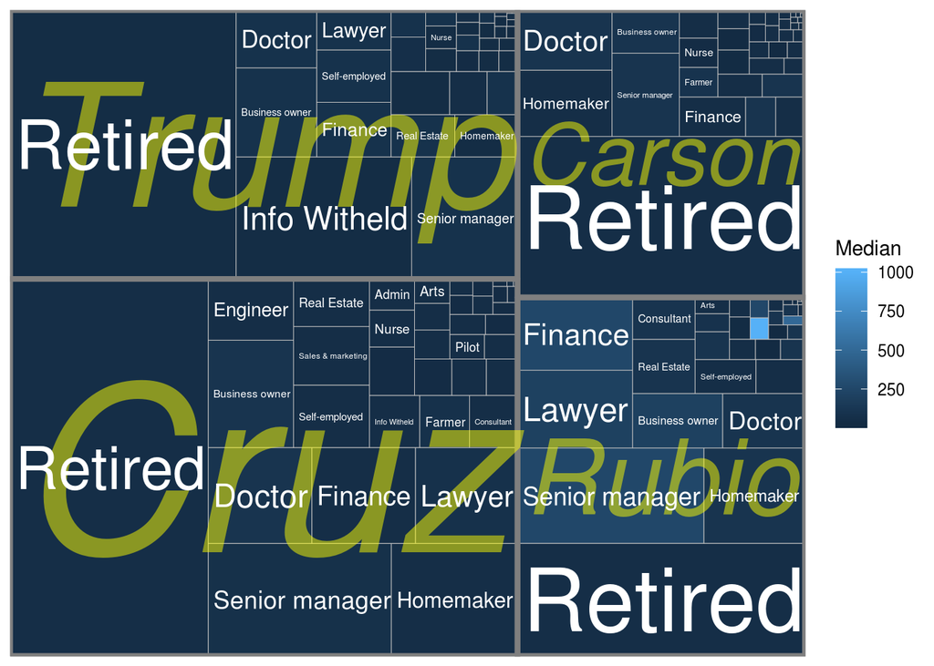

The support base for the four top Republican canidates is relatively similar, with Retired people playing a large role. Some patterns are discernible - business owners prefer Trump, homemakers prefer Cruz- but there doesn’t seem to be a particular demographic being mobilised unexpectedly (as can be seen with Sanders and unemployed donors)

Let’s use the same analysis to compare Trump and clinton in the general election:

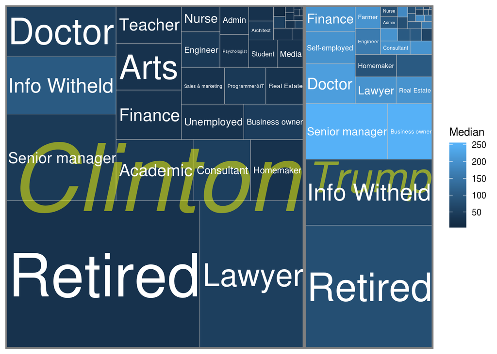

3 things stand out: (1) Clinton receives significantly more money during the general election (2) while some groups are shared, others have an aversion to Trump - e.g. teachers, academics, the unemployed, those working in the arts ; (3) groups that donate to both candidates donate much higher amounts to Trump - senior managers, doctors, lawyers.

Alluvial diagrams are another multivariate plot suitable to gaining insight into the multifaceted flows of campaign finance. Below is an alluvial diagram of contributions coming from retired donors (in million $).

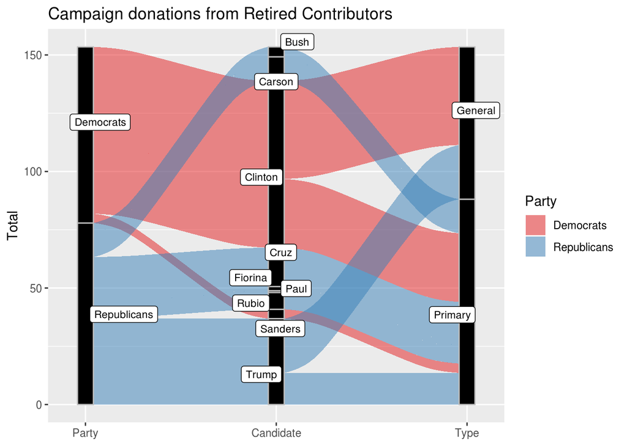

Retired donors contribute a large amount of campaign finance to both of the main parties. The majority of it is donated in the primaries. Sanders received far less money from retired contributors than Clinton. Trump was the main recipient for Republican candidates, but Clinton received significantly more than Trump, in both the primaries and the general election.

Another demographic mentioned before are the unemployed. Which candidates did they donate their money to?

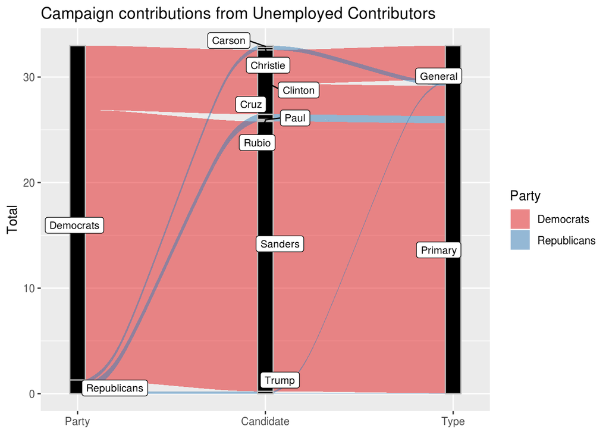

In comparison the the retired, unemployed donors contributed a lot less - just over $30 million - but they gave almost all of it to the Democrats. They had an extreme preference for Sanders - which is why almost all of their contributions were made in the primaries.

# Multivariate Analysis

### Talk about some of the relationships you observed in this part of the investigation. Were there features that strengthened each other in terms of looking at your feature(s) of interest?

The two alluvial diagrams show striking differences in the patterns of campaign donations by two large an important groups of donors: the retired and the unemployed. While the support from retired donors reflects general trends seen in the analysis, unemployed donors shunned all Republican candidates and, also largely Clinton, to give very strong financial support to Sanders.

The treemap comparing the supporters of the Clinton and Trump general election campaigns reveals some interesting aspects. While Clinton receives significantly more money during the general election, the median donations by occupation to Trump are much higher for a lot of occupations. Also, while some groups are shared, others have an aversion to Trump - e.g. teachers, academics, the unemployed, those working in the arts. Also, groups that prominently donate to both candidates, such as senior managers, doctors, lawyers, donate much higher amounts to Trump.

### Were there any interesting or surprising interactions between features?

The violon plots are a good way to compare the dynamic of the Democratic and Republican primaries races: after the other candidates left, the Democratic primaries became a “two-horse race” between Sanders and Clinton quite early on ; by comparisons, the 17 Republican candidates dropped out more gradually, leading to a more crowded field for much of the context.

# Final Plots and Summary

### Plot One

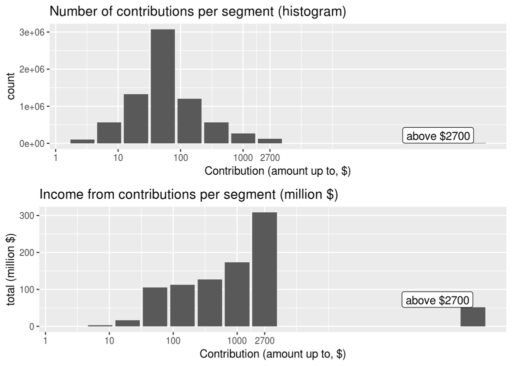

### Description One

This disparity is linked to the log-normal distribution of contributions. It expresses an important truth about campaign finance: size of donations matters. The amount of political influence that is obtained through campaign finance falls dispropotionately on the relatively small number of people who can afford to donate large amounts.

### Plot Two

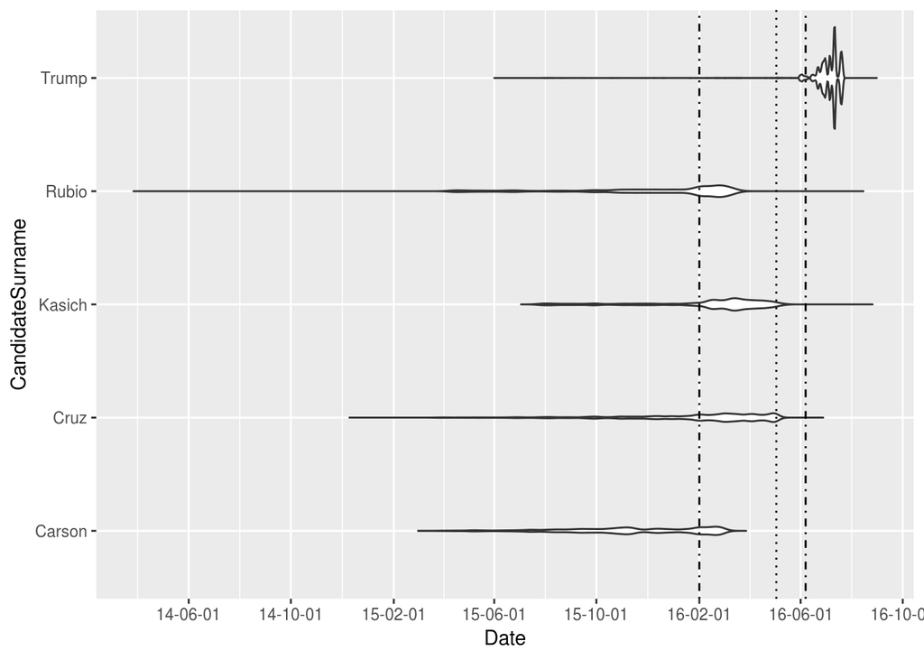

### Description Two

This plot shows the race between top candidates in the Republican primaries as it unfolds. The violin plots show the density of contributions over time (normalised to be the same for all candidates). Vertical lines show the beginning and the end of the primaries, as well as the point from which Trump becomes the sole remaining candidate, after Cruz and Kasich suspended their campaigns following the Indiana primaries on 3.May.

Rubio started to receive campaign donations since March 2014, receives the bulk of finance around the early part of the primaries - and exits after a month, on 15. March. Carson - who received a higher proportion of funding in the 6 months in the run up to the primaries start - leaves the race on 4. March.

By contrast Trump - who partially self-funded his campaign to the tune of $66 million - received the vast majority of primary contributions after the end of the primaries.

### Plot Three

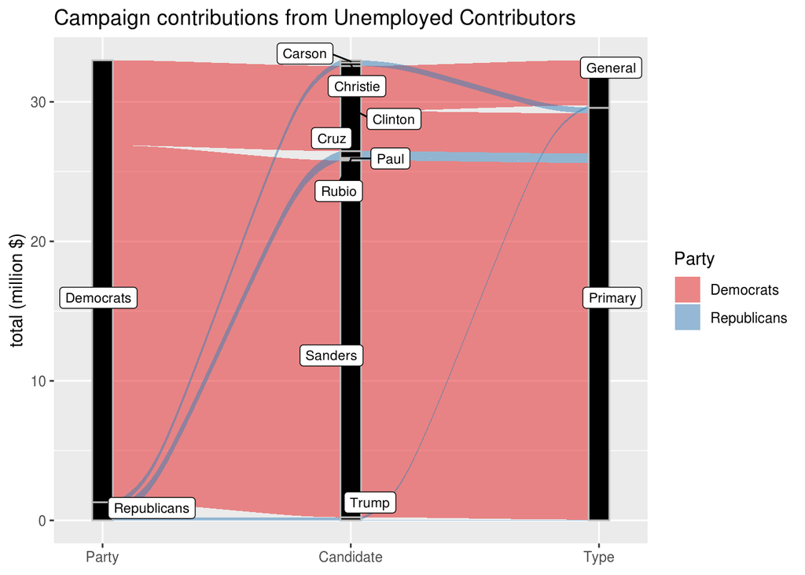

# Reflection

Really interesting to learn some new types of plots like treemaps and alluvial diagrams. Also interesting to analyse in more depth the distribution of contribution amounts and the reason behind ‘negative contributions’.

Cleaning the donor occupation data was more work than I had anticipated but once it was done it made the analysis pretty interesting. Frustratingly, a lot of the data remains un-analysed.

Perhaps it may seem questionable to choose the whole dataset of the 2016 election campaign, rather than only data for a single state. My original plan had been to also use the ZIP codes to map donors geographically, and combine this with information such as deprivation, unemployment, ethnic diversity, rural vs urban character. Trump (and to some extent Sanders) have been portrayed as ‘disruptors’ of the normal rules of US elections - it would have been very intersting to look for evidence of them mobilising particular demographics in particular areas, perhaps attempt to build a predictive model for donors in which neighbourhoods unexpectedly support a particular candidate. Unfortunately the amount of work required turned out to be beyond the scope of this project.